# Corona virus and its effect on Haiti

AS2018448

1] Location

Haiti is a north American country. which shares the island of Hispaniola with the Dominican Republic to its east.Haiti is a small country with the area of only 27,750 km2. You can be more clear about the location by considering the following map.

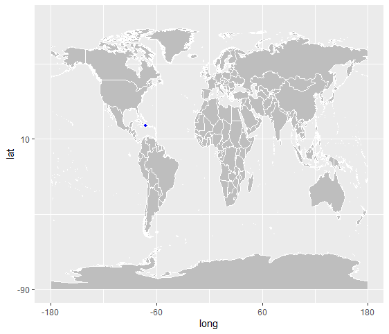

2] Atmospheric Conditions and Natural Disasters

Haiti is the 145th country considering its GDP. The country’s per capita income is very low and the population density is high. Half of the population is gathered in coastal cities, nearby floodplains and the ares with steep slopes where landslides can occur easily.Apart from this fact deforestation has become a huge problem in Haiti just like un-maintained drainage infrastructure. Due to these two factors alone, Haiti is more vulnerable to hurricanes, storm surges,flooding and increasing temperatures during dry months, strengthening. On top of all the human-made facts, the country lays near an intersection of two tectonic plates. Due to this, it faces many earthquakes and looses hundreds of its populations.

3] Actions by government and the impact on spread of the virus

Dr. Sophia Cherestal Wooley, deputy medical coordinator for Doctors Without Borders/Médecins Sans Frontières in Port-au-Prince states that “We don’t have a large quantity of people who are in bad shape.They don’t get sick to the point that they need to be hospitalized and we don’t have the same quantity of people who have died here like in the Dominican Republic.”

Even these days, Haiti has reached only 17% of the peak recording only 2 cases for 100,000 people.

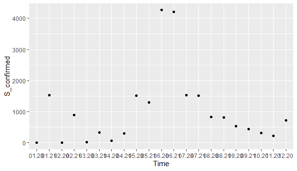

Comparing with the number of cases reported, it can be seen that the number of people who die is also low. It is a fact that the half of the countries population are less than 24 years old. Mary A. Clisbee, the director of research for Zanmi Lasante, which runs the University Hospital in Mirebalais hospital says that it has become a regular discussion about the surprising evolution of COVID-19 in Haiti.

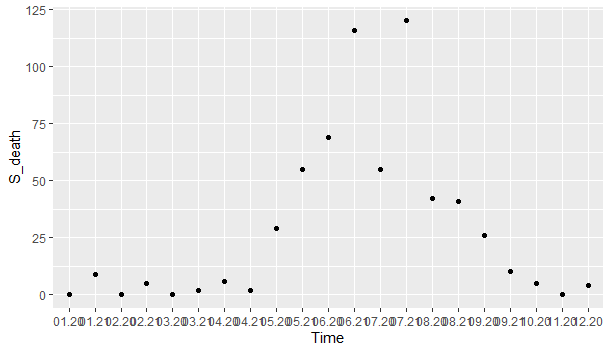

4] Conclusion

According to the data and what the experts says, Haiti is in a unique situation comparing with the other countries, given the fact that the political side of the country is also very complicated. This country has obtained its first batch of vaccine, only on 14-June-2021 which was amounted to only 500,000 where the total population of the country is nearly 11 million. If this kind of a country could survive this global pandamic better than other countries, the Haitians have proved the capability of themselves to the world.

Reference 1. https://www.paho.org/english/DD/PED/reginfohaiti.html 2.Tampa Bay Times-Published on Dec. 16, 2020 by Jacqueline Charles, Miami Herald 3.https://graphics.reuters.com/world-coronavirus-tracker-and-maps/countries-and-territories/haiti/.